# Sensitivity Analyses

## Assumptions

In observational studies, conditioning on **propensity scores** or using **g computation** can lead to unbiased estimates of the exposure effect under:

1. Consistency
2. Exchangeability
3. Positivity

**There are no unmeasured confounders**

# Quantifying Unmeasured Confounding

[figure not shown]

## Quantifying Unmeasured Confounding

1. The exposure-outcome
2. The exposure-unmeasured
3. The unmeasured confounder-outcome effect

## Quantifying Unmeasured Confounding

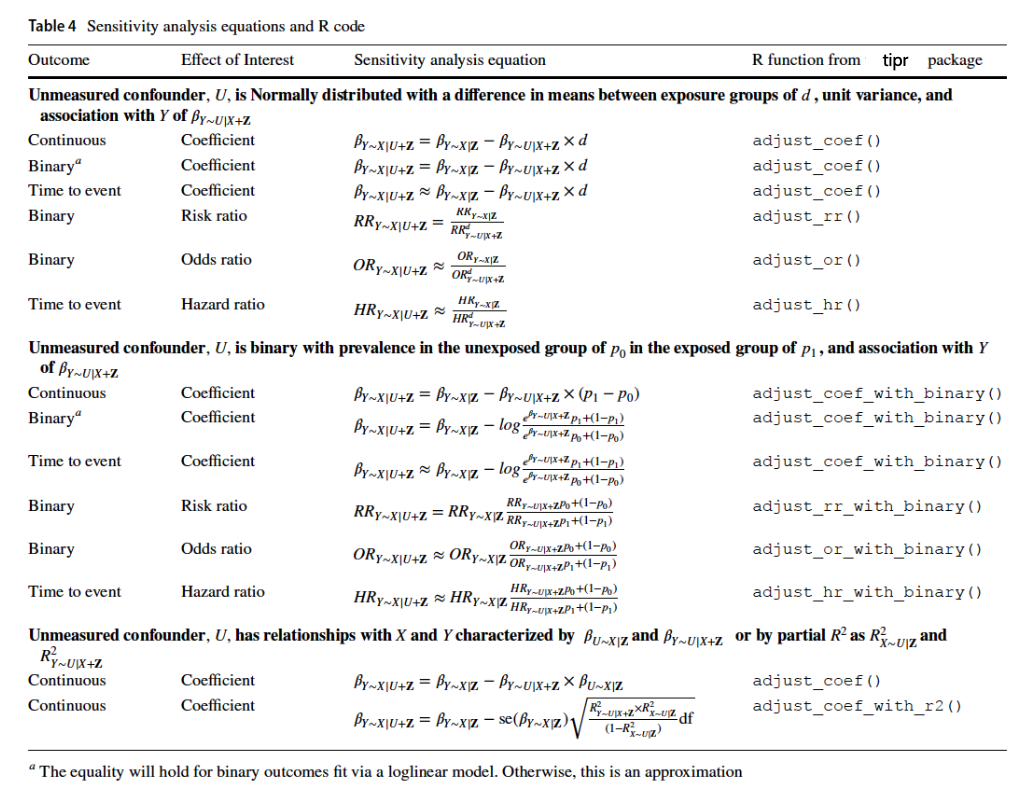

[D’Agostino McGowan, L. Sensitivity Analyses for Unmeasured Confounders. Curr Epidemiol Rep 9, 361–375 (2022)](https://doi.org/10.1007/s40471-022-00308-6)

# What will tip our confidence bound to cross zero?

## Quantifying Unmeasured Confounding

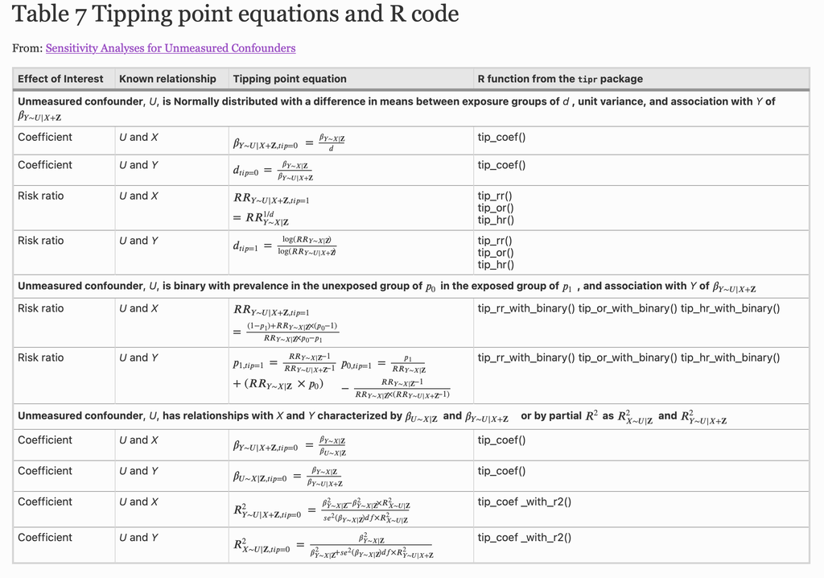

[D’Agostino McGowan, L. Sensitivity Analyses for Unmeasured Confounders. Curr Epidemiol Rep 9, 361–375 (2022)](https://doi.org/10.1007/s40471-022-00308-6)

## How to

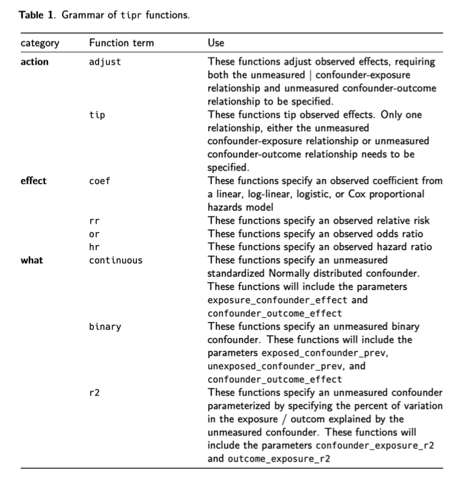

[figure not shown]

- `{action}_{effect}_with_{what}`
- `tip_rr_with_continous()`
- `adjust_coef_with_r2()`

[D’Agostino McGowan, L., (2022). tipr: An R package for sensitivity analyses for unmeasured confounders. Journal of Open Source Software, 7(77), 4495](https://doi.org/10.21105/joss.04495)

# **tipr**

## Example

[figure not shown]

## Question

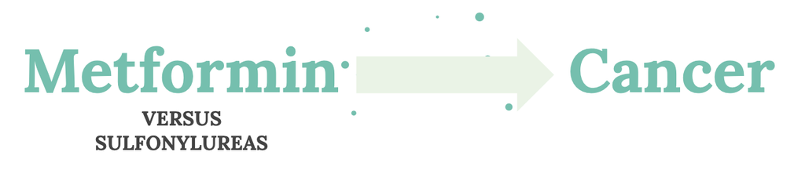

## Analysis

- New-user design
- **Matched** 42,217 new metformin users to 42,217 new sulfonylurea users
- Fit **adjusted Cox proportional hazards model** on the matched cohort

## Results

- **Outcome:** Lung Cancer
- **Adjusted Hazard Ratio**: 0.87 (0.79, 0.96)

# What if **alcohol consumption** is an unmeasured confounder?

# What if heavy alcohol consumption is prevalent among *4%* of Metformin users and *6%* of Sulfonylurea users?

Meadows SO, Engel CC, Collins RL, Beckman RL, Cefalu M, Hawes-Dawson J, et al. 2015 health related behaviors survey: Substance use among US active-duty service members. RAND; 2018.

## `tipr` Example

**What if we assume the effect of alcohol consumption on lung cancer after adjusting for other confounders is 2?**

```r
library(tipr)
adjust_hr_with_binary(
  effect_observed = c(0.79, 0.87, 0.96),
  exposed_confounder_prev = .04,
  unexposed_confounder_prev = .06,
  confounder_outcome_effect = 2)
```

## `tipr` Example

**What if we assume the effect of alcohol consumption on lung cancer after adjusting for other confounders is 2?**

```r
library(tipr)
adjust_hr_with_binary(
  effect_observed = c(0.79, 0.87, 0.96),
  exposed_confounder_prev = .04,
  unexposed_confounder_prev = .06,
  confounder_outcome_effect = 2)
```

## Results

- **Outcome:** Lung Cancer
- **Adjusted Hazard Ratio**: 0.87 (0.79, 0.96)

## `tipr` Example

**What if we assume the effect of alcohol consumption on lung cancer after adjusting for other confounders is 2?**

```r
library(tipr)
adjust_hr_with_binary(
  effect_observed = c(0.79, 0.87, 0.96),
  exposed_confounder_prev = .04,
  unexposed_confounder_prev = .06,
  confounder_outcome_effect = 2)
```

# What if heavy alcohol consumption is prevalent among *4%* of Metformin users and *6%* of Sulfonylurea users?

Meadows SO, Engel CC, Collins RL, Beckman RL, Cefalu M, Hawes-Dawson J, et al. 2015 health related behaviors survey: Substance use among US active-duty service members. RAND; 2018.

## `tipr` Example

*What if we assume the effect of alcohol consumption on lung cancer after adjusting for other confounders is 2?*

```r
library(tipr)
adjust_hr_with_binary(
  effect_observed = c(0.79, 0.87, 0.96),
  exposed_confounder_prev = .04,
  unexposed_confounder_prev = .06,
  confounder_outcome_effect = 2)
```

## `tipr` Example

```
# A tibble: 3 × 5
  hr_adjusted hr_observed exposed_confounder_prev unexposed_confounder_prev
        <dbl>       <dbl>                   <dbl>                     <dbl>
1       0.805        0.79                    0.04                      0.06
2       0.887        0.87                    0.04                      0.06
3       0.978        0.96                    0.04                      0.06
# ℹ 1 more variable: confounder_outcome_effect <dbl>
```